# Workflow Basics and ggplot2 in R

Robin Choudhury  
2018-07-04

### Workflow Basics in R

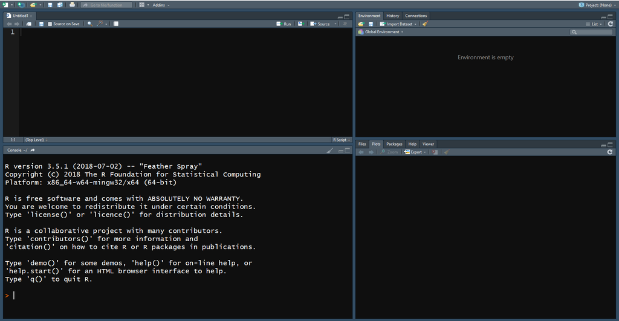

For this Section we will be using RStudio

### Coding Basics 1

R can work like a calculator…

```r
1 / 200 * 30
```

```
[1] 0.15
```

```r
pi *3
```

```
[1] 9.424778
```

Base R knows `pi` as the constant `3.14...`.

### Coding Basics 2

R can also handle text…

```r
print("Hello, World!")
```

```
[1] "Hello, World!"
```

And can mix text and calculations…

```r
paste("The value of pi is", pi)
```

```
[1] "The value of pi is 3.14159265358979"
```

### Coding Basics 3

You can also create new objects with `<-`

```r
a <- 1 / 200 * 30; a
```

```
[1] 0.15
```

Then use those objects in subsequent calculations

```r
a*3
```

```
[1] 0.45
```

### Coding Basics 4

Object names must start with a letter, and needs to contain letters, numbers, **_**, and **.**

You can make assignments with either **<-** or **=**, but most people prefer **<-**. Using **<-** originated when APL computers had a single <- key on them (see http://blog.revolutionanalytics.com/2008/12/use-equals-or-arrow-for-assignment.html for more info).

R is case sensitive, so **A** will not tell you the value of **a**

### ggplot2 and the Aesthetic of Graphics

ggplot2 is part of a a suite of packages in R known colloquially as the 'Tidyverse'. ggplot2 was developed to build graphs by mapping aesthetics, allowing users to flexibly create beautiful publication-quality figures.

```r
library(tidyverse)
library(datasets)
```

### The Dataset

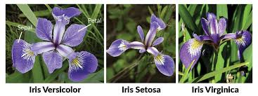

I will be using the iris dataset:

- Common example dataset
- Fairly compact (150 obs. of 5 variables)
- Flower measurement of 3 iris species

```r
data(iris)
```

### ggplot2 Basics: Making the First Call

As mentioned earlier, ggplot2 works by layering on different aesthetics from a dataset. ggplot2 first needs to know what dataset you plan to use, and what will be plotted.

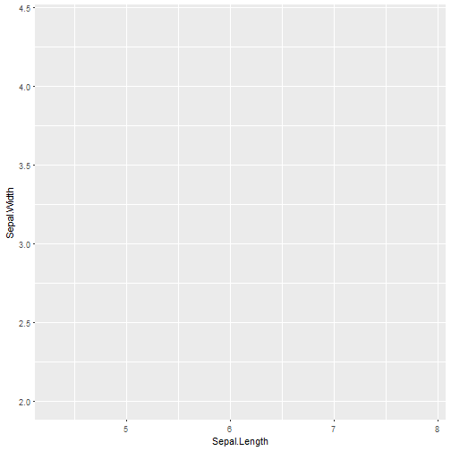

```r
ggplot(data=iris, aes(x = Sepal.Length,y = Sepal.Width))
```

…pretty boring. Why?

### ggplot2 Basics: Adding Aesthetics

Now we want to use a scatterplot method to mark out these two variables.

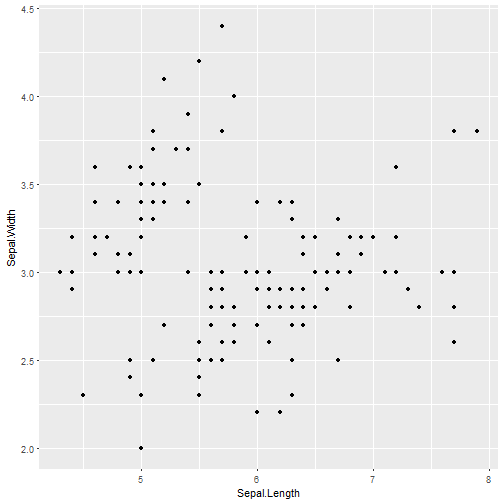

```r
ggplot(data=iris, aes(x = Sepal.Length,y = Sepal.Width))+
  geom_point()
```

### ggplot2 Basics: Adding Smoothing Functions

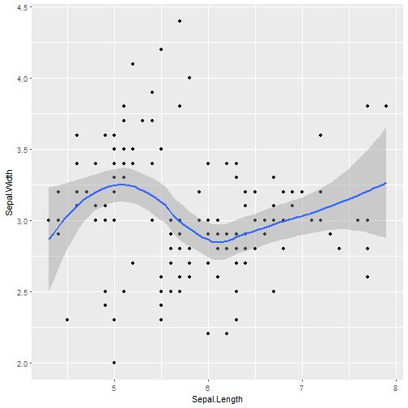

```r
ggplot(data=iris, aes(x = Sepal.Length,y = Sepal.Width))+
  geom_point() + geom_smooth()
```

### ggplot2 Basics: Color Points By Species

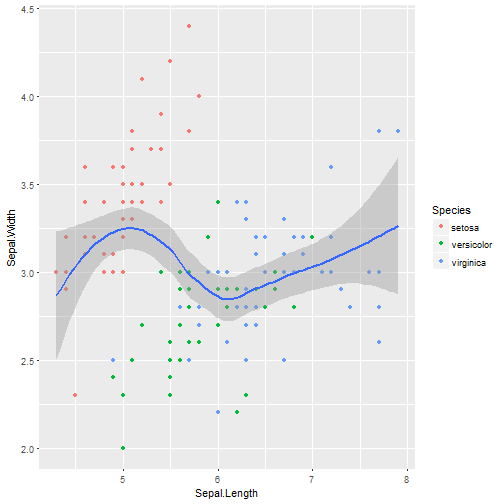

```r
ggplot(data=iris, aes(x = Sepal.Length,y = Sepal.Width))+
  geom_point(aes(color=Species)) + geom_smooth()
```

### ggplot2 Basics: Size by Petal Length

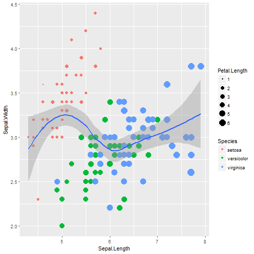

```r
ggplot(data=iris, aes(x = Sepal.Length,y = Sepal.Width))+
  geom_point(aes(color=Species, size=Petal.Length)) + geom_smooth()
```

### ggplot2 Basics: Color Lines and Points By Species

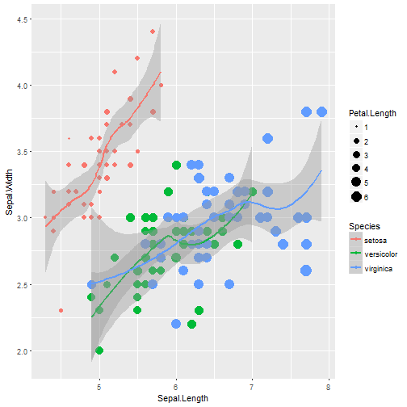

```r
ggplot(data=iris, aes(x = Sepal.Length,y = Sepal.Width,color=Species))+
  geom_point(aes(size=Petal.Length)) + geom_smooth()
```

### ggplot2 Basics: Use Linear Smoothing

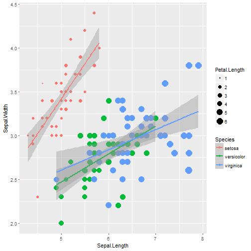

```r
ggplot(data=iris, aes(x = Sepal.Length,y = Sepal.Width,color=Species))+
  geom_point(aes(size=Petal.Length)) + geom_smooth(method="lm")
```

### ggplot2 Basics: Different Line Types

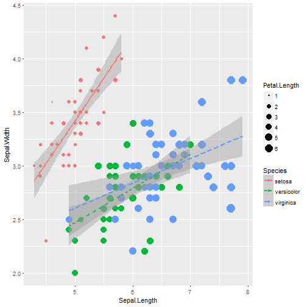

```r
ggplot(data=iris, aes(x = Sepal.Length,y = Sepal.Width,color=Species))+
  geom_point(aes(size=Petal.Length)) + geom_smooth(aes( linetype=Species), method="lm")
```

### ggplot2 Basics: Rug Really Ties the Room Together

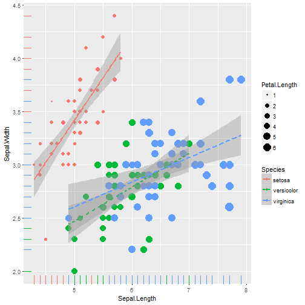

```r
ggplot(data=iris, aes(x = Sepal.Length,y = Sepal.Width,color=Species))+
  geom_point(aes(size=Petal.Length)) + geom_smooth(aes( linetype=Species), method="lm") +
  geom_rug()
```

### ggplot2 Basics: Density

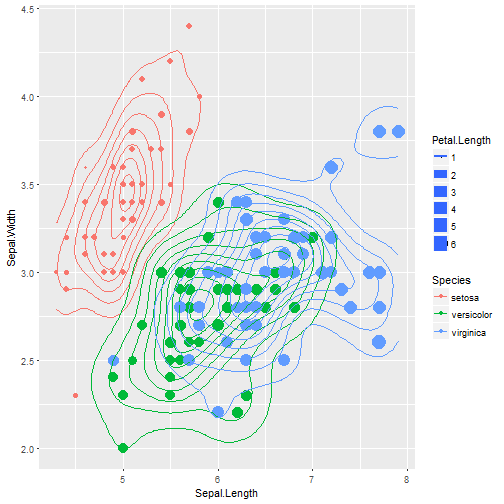

```r
ggplot(data=iris, aes(x = Sepal.Length,y = Sepal.Width,color=Species))+
  geom_point(aes(size=Petal.Length)) +
  geom_density2d()
```

### ggplot2 Basics: Hex

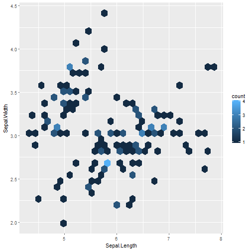

```r
ggplot(data=iris, aes(x = Sepal.Length,y = Sepal.Width))+
  geom_hex()
```

### ggplot2 Basics: Histograms

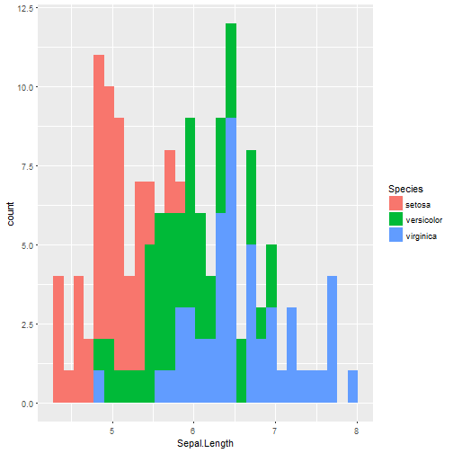

```r
ggplot(data=iris, aes(Sepal.Length,fill=Species))+
geom_histogram()
```

### ggplot2 Basics: Histograms with Dodge

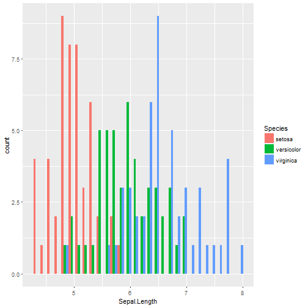

```r
ggplot(data=iris, aes(Sepal.Length,fill=Species))+
geom_histogram(position = "dodge")
```

### ggplot2 Basics: Fill vs. Color

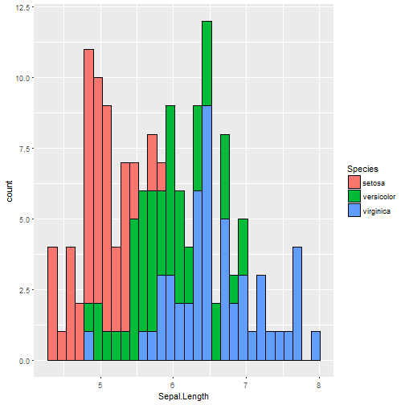

```r
ggplot(data=iris, aes(Sepal.Length,fill=Species))+
geom_histogram(color="black")
```

### ggplot2 Basics: Inside vs. Outside of Aes

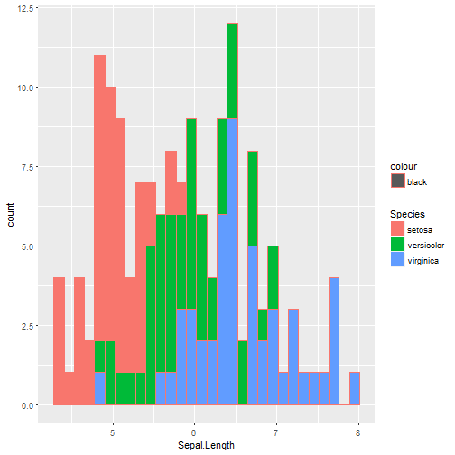

```r
ggplot(data=iris, aes(Sepal.Length,fill=Species))+
geom_histogram(aes(color="black"))
```

### ggplot2 Basics: Alpha

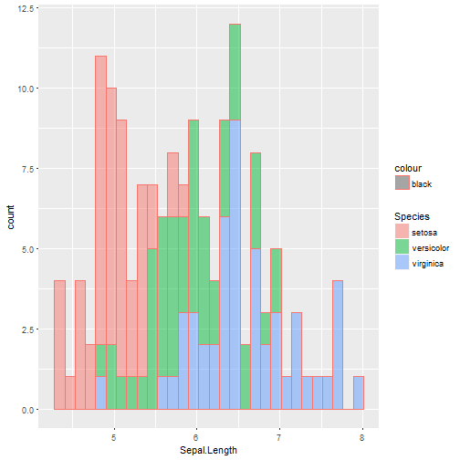

```r
ggplot(data=iris, aes(Sepal.Length,fill=Species))+
geom_histogram(aes(color="black"), alpha=0.5)
```

### ggplot2 Basics: Theme

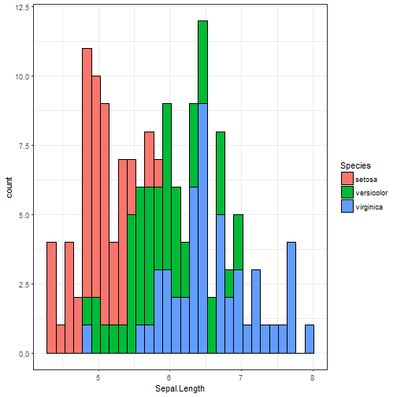

```r
ggplot(data=iris, aes(Sepal.Length,fill=Species))+
geom_histogram(color="black")+
  theme_bw()
```

### ggplot2 Basics: Theme

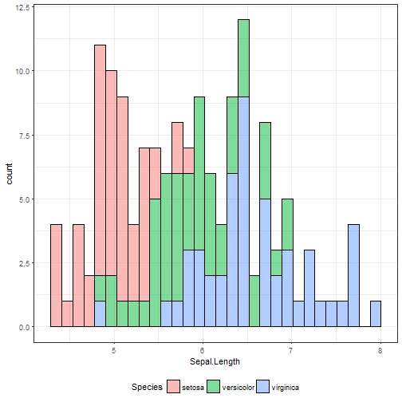

```r
ggplot(data=iris, aes(Sepal.Length,fill=Species))+
geom_histogram(color="black", alpha=0.5)+
  theme_bw() +
  theme(legend.position="bottom")
```

### ggplot2 Basics: Theme

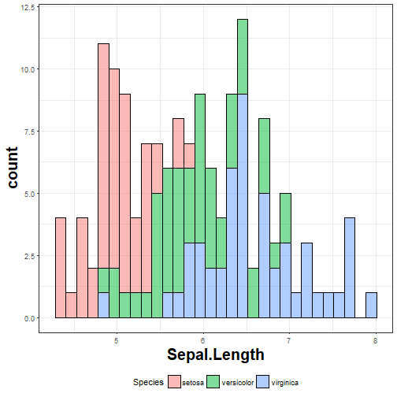

```r
ggplot(data=iris, aes(Sepal.Length,fill=Species))+
geom_histogram(color="black", alpha=0.5)+
  theme_bw() +
  theme(legend.position="bottom",
        axis.title=element_text(size=20, face="bold"))
```

### ggplot2 Basics: Axis Labels

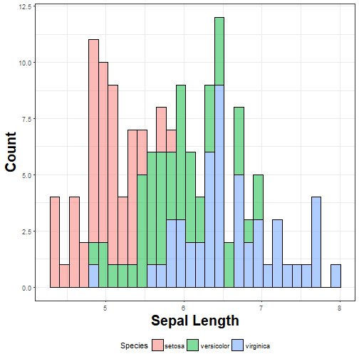

```r
ggplot(data=iris, aes(Sepal.Length,fill=Species))+
geom_histogram(color="black", alpha=0.5)+
  theme_bw() + ylab("Count")+xlab("Sepal Length")+
  theme(legend.position="bottom",
        axis.title=element_text(size=20, face="bold"))
```

### ggplot2 Basics: stat_ vs geom_

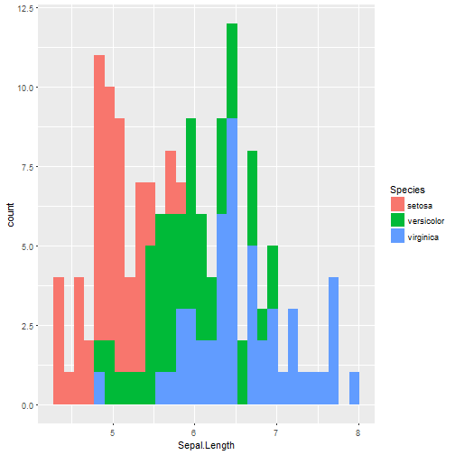

```r
ggplot(data=iris, aes(Sepal.Length,fill=Species))+
stat_bin()
```

### ggplot2 Basics: Multiple Datasets

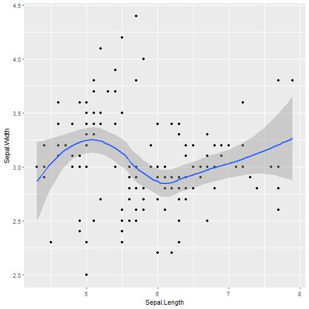

```r
ggplot()+
  geom_point(data=iris, aes(Sepal.Length, Sepal.Width))+
  geom_smooth(data=iris, aes(Sepal.Length, Sepal.Width ))
```

### ggplot2 Basics: Summarizing Data with Boxplots

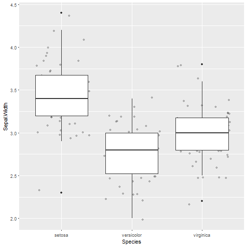

```r
ggplot(data=iris, aes(Species, Sepal.Width))+
  geom_jitter(alpha=0.2)+ geom_boxplot()
```

ORDER MATTERS!

### ggplot2 Basics: Faceting Data

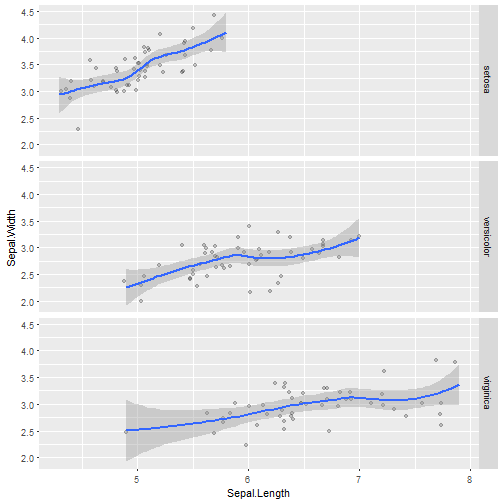

```r
ggplot(data=iris, aes(Sepal.Length, Sepal.Width))+
  geom_jitter(alpha=0.2)+ geom_smooth()+
  facet_grid(Species~.)
```

### ggplot2 Basics: Maps

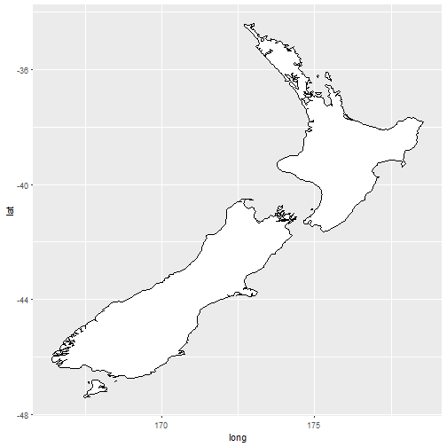

```r
nz <- map_data("nz")
ggplot(nz, aes(long, lat, group = group)) +
  geom_polygon(fill = "white", colour = "black")+
  coord_cartesian()
```

### ggplot2 Basics: Maps

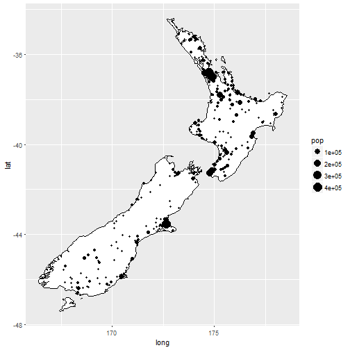

```r
data("world.cities")
nz.city <- world.cities %>% filter(country.etc=="New Zealand")
ggplot(data=nz, aes(long, lat)) +
  geom_polygon(aes(group = group),fill = "white", colour = "black") +
  geom_point(data=nz.city, aes(long, lat, size = pop)) +
  coord_cartesian()
```